# World Population

Objectives:

- Understand and clean data
- Analyze and visualize world population data
- Understand correlations and fit model (In progress)
- Predict population growth (Planned)

## Understand and clean data

- Read data from sources and print summaries

```python
import pandas as pd

# Read the CSV files
world_pop = pd.read_csv('world_pop_data.csv')
country = pd.read_csv('metadata_country.csv')

# Display basic information
print("World Population Data:")
print(world_pop.head())
print(f"Shape: {world_pop.shape}")
print("Metadata Country:")
print(country.head())
print(f"Shape: {country.shape}")
```

```
World Population Data:
  Country Code     Indicator Name Indicator Code         1960         1961  \
0          ABW  Population, total    SP.POP.TOTL      54208.0      55434.0
1          AFE  Population, total    SP.POP.TOTL  130836765.0  134159786.0
2          AFG  Population, total    SP.POP.TOTL    8996967.0    9169406.0
3          AFW  Population, total    SP.POP.TOTL   96396419.0   98407221.0
4          AGO  Population, total    SP.POP.TOTL    5454938.0    5531451.0

          1962         1963         1964         1965         1966  ...  \
0      56234.0      56699.0      57029.0      57357.0      57702.0  ...
1  137614644.0  141202036.0  144920186.0  148769974.0  152752671.0  ...
2    9351442.0    9543200.0    9744772.0    9956318.0   10174840.0  ...
3  100506960.0  102691339.0  104953470.0  107289875.0  109701811.0  ...
4    5608499.0    5679409.0    5734995.0    5770573.0    5781305.0  ...

```

[output cut: 38 more lines]

Check to see if indicator name and code has any significiance.

```
Indicator Code Counts:
Indicator Code
SP.POP.TOTL    266
Name: count, dtype: int64
```

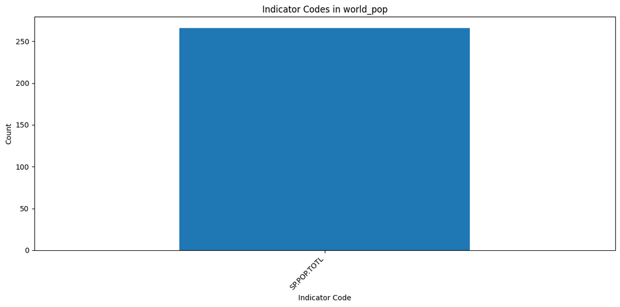

```python
import matplotlib.pyplot as plt

# Histogram-like count plot for Indicator Code (categorical)
indicator_counts = world_pop['Indicator Code'].value_counts()

print("Indicator Code Counts:")
print(indicator_counts)

plt.figure(figsize=(12, 6))
indicator_counts.plot(kind='bar')
plt.title('Indicator Codes in world_pop')
plt.xlabel('Indicator Code')
plt.ylabel('Count')
plt.xticks(rotation=45, ha='right')
plt.tight_layout()
plt.show()
```

Indicator codes are identical in all rows, thus there is not significiance. We will remove them in order to save memory during analyzing and model fitting.

```python
world_pop = world_pop.drop(columns=['Indicator Name', 'Indicator Code'])

print(world_pop.head())
print(f"Updated shape: {world_pop.shape}")
```

```
  Country Code         1960         1961         1962         1963  \
0          ABW      54208.0      55434.0      56234.0      56699.0
1          AFE  130836765.0  134159786.0  137614644.0  141202036.0
2          AFG    8996967.0    9169406.0    9351442.0    9543200.0
3          AFW   96396419.0   98407221.0  100506960.0  102691339.0
4          AGO    5454938.0    5531451.0    5608499.0    5679409.0

          1964         1965         1966         1967         1968  ...  \
0      57029.0      57357.0      57702.0      58044.0      58377.0  ...
1  144920186.0  148769974.0  152752671.0  156876454.0  161156430.0  ...
2    9744772.0    9956318.0   10174840.0   10399936.0   10637064.0  ...
3  104953470.0  107289875.0  109701811.0  112195950.0  114781116.0  ...
4    5734995.0    5770573.0    5781305.0    5774440.0    5771973.0  ...

          2011         2012         2013         2014         2015  \
0     102050.0     102565.0     103165.0     103776.0     104339.0
1  532760424.0  547482863.0  562601578.0  578075373.0  593871847.0
2   30117411.0   31161378.0   32269592.0   33370804.0   34413603.0
3  360285439.0  370243017.0  380437896.0  390882979.0  401586651.0
4   24220660.0   25107925.0   26015786.0   26941773.0   27884380.0

          2016         2017         2018         2019         2020
0     104865.0     105361.0     105846.0     106310.0     106766.0
1  609978946.0  626392880.0  643090131.0  660046272.0  677243299.0
2   35383028.0   36296111.0   37171922.0   38041757.0   38928341.0
3  412551299.0  423769930.0  435229381.0  446911598.0  458803476.0
4   28842482.0   29816769.0   30809787.0   31825299.0   32866268.0

[5 rows x 62 columns]
Updated shape: (266, 62)
```

Looking at the country table, some region values are "NaN" and the table name column and Google searching the country codes indicate they are actually regions consisting of multiple countries, so we are removing these from the world population table.

```python
# Get country codes where Region is NaN
region_nan_codes = country[country['Region'].isna()]['Country Code']

# Remove those rows from world_pop
world_pop = world_pop[~world_pop['Country Code'].isin(region_nan_codes)]

print(f"Removed {len(region_nan_codes)} region rows")
print(f"Updated shape: {world_pop.shape}")
print(world_pop.head())
```

```
Removed 48 region rows
Updated shape: (218, 62)
  Country Code       1960       1961       1962       1963       1964  \
0          ABW    54208.0    55434.0    56234.0    56699.0    57029.0
2          AFG  8996967.0  9169406.0  9351442.0  9543200.0  9744772.0
4          AGO  5454938.0  5531451.0  5608499.0  5679409.0  5734995.0
5          ALB  1608800.0  1659800.0  1711319.0  1762621.0  1814135.0
6          AND    13410.0    14378.0    15379.0    16407.0    17466.0

        1965        1966        1967        1968  ...        2011        2012  \
0    57357.0     57702.0     58044.0     58377.0  ...    102050.0    102565.0
2  9956318.0  10174840.0  10399936.0  10637064.0  ...  30117411.0  31161378.0
4  5770573.0   5781305.0   5774440.0   5771973.0  ...  24220660.0  25107925.0
5  1864791.0   1914573.0   1965598.0   2022272.0  ...   2905195.0   2900401.0
6    18542.0     19646.0     20760.0     21886.0  ...     83748.0     82427.0
```

[output cut: 16 more lines]

Years are represented in the columns. In order to analyze the data, we will convert the data so that years are represented as rows.

```python
# Convert from wide format (years as columns) to long format (years as rows)
world_pop_long = world_pop.melt(
    id_vars='Country Code',
    var_name='Year',
    value_name='Population'
)

# Clean and standardize types
world_pop_long['Year'] = world_pop_long['Year'].astype(int)
world_pop_long = world_pop_long.sort_values(['Country Code', 'Year']).reset_index(drop=True)

print(world_pop_long.head())
print(f"Long format shape: {world_pop_long.shape}")
```

```
  Country Code  Year  Population
0          ABW  1960     54208.0
1          ABW  1961     55434.0
2          ABW  1962     56234.0
3          ABW  1963     56699.0
4          ABW  1964     57029.0
Long format shape: (13298, 3)
```

We will check if all countries have population data for all the years.

```python
# Check coverage: does each country have data for every year in the dataset?
expected_years = set(world_pop_long["Year"].unique())
expected_count = len(expected_years)

country_year_counts = world_pop_long.groupby("Country Code")["Year"].nunique()
incomplete_countries = country_year_counts[country_year_counts < expected_count]

print(f"Expected number of years per country: {expected_count}")
print(f"Total countries: {country_year_counts.shape[0]}")
print(f"Countries with complete year coverage: {(country_year_counts == expected_count).sum()}")
print(f"Countries with missing years: {incomplete_countries.shape[0]}")

if incomplete_countries.empty:
	print("All countries have population data for all years.")
else:
	print("\nCountries with missing years:")
	print(incomplete_countries.sort_values())

	# Optional: show exactly which years are missing for each incomplete country
	missing_years_by_country = (
		world_pop_long.groupby("Country Code")["Year"]
		.apply(lambda s: sorted(expected_years - set(s)))
		.loc[incomplete_countries.index]
	)
	print("\nMissing years by country:")
	print(missing_years_by_country)
```

```
Expected number of years per country: 61
Total countries: 218
Countries with complete year coverage: 218
Countries with missing years: 0
All countries have population data for all years.
```

Now we are sure that all the countries have all the population data for the years given.

Let's explore the income groups in the country table. We will prepare a histogram.

```
Income Group Counts:
IncomeGroup
High income            79
Lower middle income    55
Upper middle income    55
Unknown                49
Low income             27
Name: count, dtype: int64
```

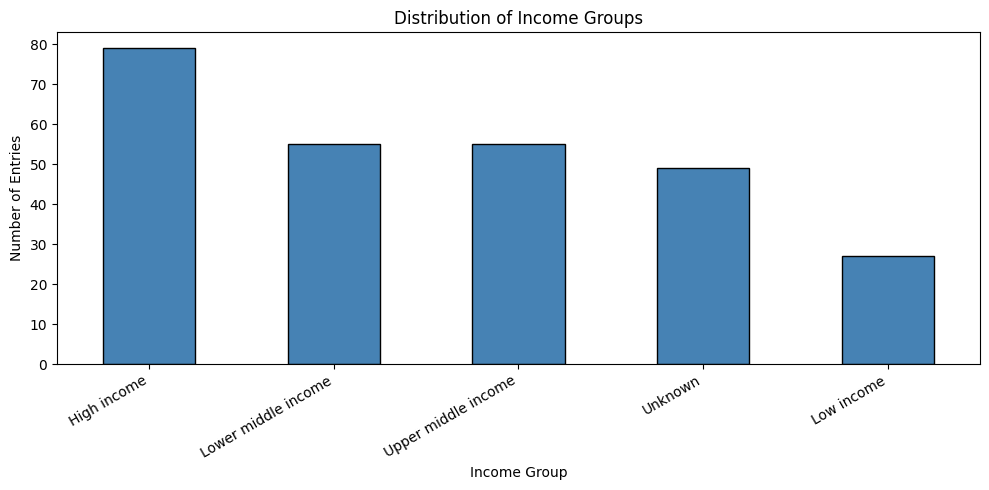

```python
# Count countries by income group (including missing values as "Unknown")
income_counts = country["IncomeGroup"].fillna("Unknown").value_counts()

print("Income Group Counts:")
print(income_counts)

plt.figure(figsize=(10, 5))
income_counts.plot(kind="bar", color="steelblue", edgecolor="black")
plt.title("Distribution of Income Groups")
plt.xlabel("Income Group")
plt.ylabel("Number of Entries")
plt.xticks(rotation=30, ha="right")
plt.tight_layout()
plt.show()
```

We will remove the countries with income group "Unknown" (NaN) from the world population data.

```python
# Get country codes where IncomeGroup is NaN
unknown_income_codes = country[country['IncomeGroup'].isna()]['Country Code']

# Remove those rows from world_pop_long
world_pop_long = world_pop_long[~world_pop_long['Country Code'].isin(unknown_income_codes)]

print(f"Removed {len(unknown_income_codes)} countries with unknown income group")
print(f"Updated shape: {world_pop_long.shape}")
print(world_pop_long.head())
```

```
Removed 49 countries with unknown income group
Updated shape: (13237, 3)
  Country Code  Year  Population
0          ABW  1960     54208.0
1          ABW  1961     55434.0
2          ABW  1962     56234.0
3          ABW  1963     56699.0
4          ABW  1964     57029.0
```

Let's remember the country table before merging them into one table for data analysis.

```python
print(country.head())
```

```
  Country Code                     Region          IncomeGroup  \
0          ABW  Latin America & Caribbean          High income
1          AFE                        NaN                  NaN
2          AFG                 South Asia           Low income
3          AFW                        NaN                  NaN
4          AGO         Sub-Saharan Africa  Lower middle income

                                        SpecialNotes  \
0                                                NaN
1  26 countries, stretching from the Red Sea in t...
2  Fiscal year end: March 20; reporting period fo...
3  22 countries, stretching from the westernmost ...
4                                                NaN

                     TableName
0                        Aruba
1  Africa Eastern and Southern
2                  Afghanistan
3   Africa Western and Central
4                       Angola
```

Let's add country name, region name, and income group into the world population table.

```python
world_pop_long = world_pop_long.merge(country[['Country Code', 'Region', 'IncomeGroup', 'TableName']], on='Country Code', how='left')
world_pop_long = world_pop_long.rename(columns={'TableName': 'Country Name'})
print(world_pop_long.head())
```

```
  Country Code  Year  Population                     Region  IncomeGroup  \
0          ABW  1960     54208.0  Latin America & Caribbean  High income
1          ABW  1961     55434.0  Latin America & Caribbean  High income
2          ABW  1962     56234.0  Latin America & Caribbean  High income
3          ABW  1963     56699.0  Latin America & Caribbean  High income
4          ABW  1964     57029.0  Latin America & Caribbean  High income

  Country Name
0        Aruba
1        Aruba
2        Aruba
3        Aruba
4        Aruba
```

We do not need the long and inconvenient name for the world pop table. Let's rename it to have the shorter name again.

```python
# Free memory by deleting the original world_pop dataframe if it's no longer needed
# Free memory by deleting the country table if it's no longer needed after merging
del world_pop
del country

# Reuse the existing long-format dataframe with a shorter name (no data copy)
world_pop = world_pop_long
del world_pop_long  # remove extra reference to keep memory usage lower

print(world_pop.head())
print(f"Shape: {world_pop.shape}")
```

```
  Country Code  Year  Population                     Region  IncomeGroup  \
0          ABW  1960     54208.0  Latin America & Caribbean  High income
1          ABW  1961     55434.0  Latin America & Caribbean  High income
2          ABW  1962     56234.0  Latin America & Caribbean  High income
3          ABW  1963     56699.0  Latin America & Caribbean  High income
4          ABW  1964     57029.0  Latin America & Caribbean  High income

  Country Name
0        Aruba
1        Aruba
2        Aruba
3        Aruba
4        Aruba
Shape: (13237, 6)
```

## Analyze and visualize world population data

Let's compare the populations by each region.

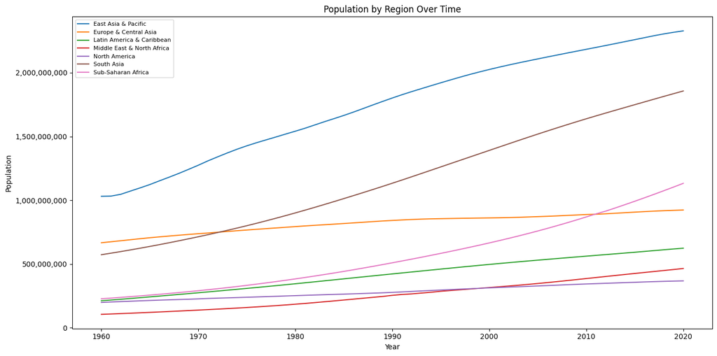

```python
from matplotlib.ticker import StrMethodFormatter

# Aggregate total population by region and year
region_pop = world_pop.groupby(['Region', 'Year'])['Population'].sum().reset_index()

# Plot population over time for each region
plt.figure(figsize=(14, 7))
for region, group in region_pop.groupby('Region'):
    plt.plot(group['Year'], group['Population'], label=region)

plt.title('Population by Region Over Time')
plt.xlabel('Year')
plt.ylabel('Population')
plt.gca().yaxis.set_major_formatter(StrMethodFormatter('{x:,.0f}'))
plt.legend(loc='upper left', fontsize=8)
plt.tight_layout()
plt.show()
```

Let's check the region and income group bubble chart.

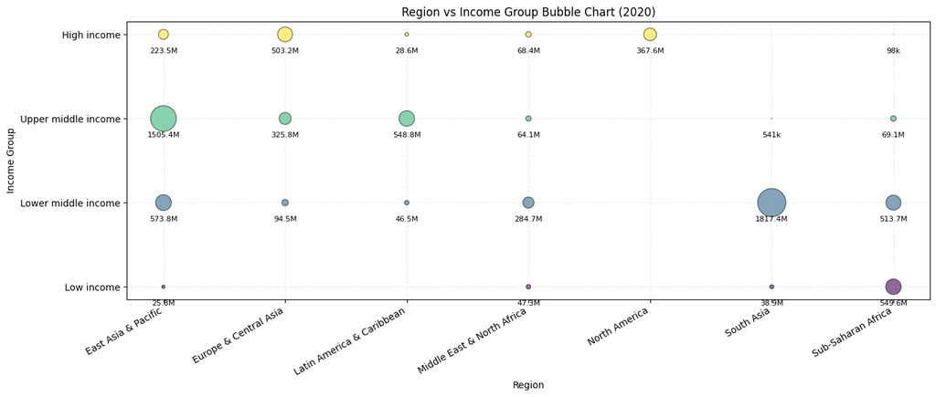

```python
# Bubble chart: Region vs Income Group (using latest available year)
latest_year = world_pop["Year"].max()

bubble_data = (
    world_pop[world_pop["Year"] == latest_year]
    .groupby(["Region", "IncomeGroup"], as_index=False)["Population"]
    .sum()
)

# Ordered categories for clearer y-axis
income_order = ["Low income", "Lower middle income", "Upper middle income", "High income"]
regions = sorted(bubble_data["Region"].unique())

region_to_x = {r: i for i, r in enumerate(regions)}
income_to_y = {g: i for i, g in enumerate(income_order)}

bubble_data["x"] = bubble_data["Region"].map(region_to_x)
bubble_data["y"] = bubble_data["IncomeGroup"].map(income_to_y)

# Scale bubble sizes
bubble_data["size"] = bubble_data["Population"] / 2_000_000  # tune divisor for readability

plt.figure(figsize=(14, 6))
plt.scatter(
    bubble_data["x"],
    bubble_data["y"],
    s=bubble_data["size"],
    c=bubble_data["y"],
    cmap="viridis",
    alpha=0.6,
    edgecolors="black",
    linewidth=0.8
)
# Add population labels beneath each bubble (k/M format)
for _, r in bubble_data.iterrows():
    pop = r["Population"]
    if pop >= 1_000_000:
        label = f"{pop / 1_000_000:.1f}M"
    elif pop >= 1_000:
        label = f"{pop / 1_000:.0f}k"
    else:
        label = f"{int(pop)}"

    plt.text(
        r["x"],
        r["y"] - 0.16,   # place text beneath bubble
        label,
        ha="center",
        va="top",
        fontsize=8,
        color="black"
    )
plt.xticks(range(len(regions)), regions, rotation=30, ha="right")
plt.yticks(range(len(income_order)), income_order)
plt.title(f"Region vs Income Group Bubble Chart ({latest_year})")
plt.xlabel("Region")
plt.ylabel("Income Group")
plt.grid(axis="both", linestyle="--", alpha=0.25)
plt.tight_layout()
plt.show()
```

Let's check the region and income group bubble chart to see how many countries are in each cross grouping.

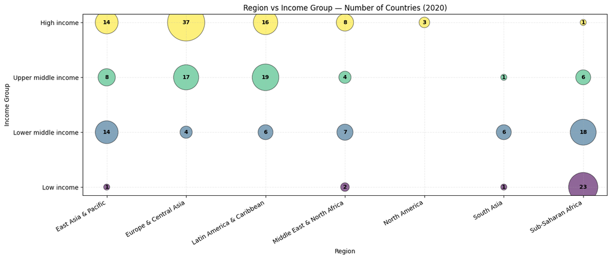

```
                        Region          IncomeGroup  Country Count
0          East Asia & Pacific          High income             14
1          East Asia & Pacific           Low income              1
2          East Asia & Pacific  Lower middle income             14
3          East Asia & Pacific  Upper middle income              8
4        Europe & Central Asia          High income             37
5        Europe & Central Asia  Lower middle income              4
6        Europe & Central Asia  Upper middle income             17
7    Latin America & Caribbean          High income             16
8    Latin America & Caribbean  Lower middle income              6
9    Latin America & Caribbean  Upper middle income             19
10  Middle East & North Africa          High income              8
11  Middle East & North Africa           Low income              2
12  Middle East & North Africa  Lower middle income              7
13  Middle East & North Africa  Upper middle income              4
14               North America          High income              3
15                  South Asia           Low income              1
16                  South Asia  Lower middle income              6
17                  South Asia  Upper middle income              1
18          Sub-Saharan Africa          High income              1
19          Sub-Saharan Africa           Low income             23
20          Sub-Saharan Africa  Lower middle income             18
21          Sub-Saharan Africa  Upper middle income              6
```

```python
# Count countries in each Region x IncomeGroup combination (latest year)
country_counts = (
    world_pop[world_pop["Year"] == latest_year]
    .groupby(["Region", "IncomeGroup"], as_index=False)["Country Code"]
    .nunique()
    .rename(columns={"Country Code": "Country Count"})
)

country_counts["x"] = country_counts["Region"].map(region_to_x)
country_counts["y"] = country_counts["IncomeGroup"].map(income_to_y)

plt.figure(figsize=(14, 6))
scatter = plt.scatter(
    country_counts["x"],
    country_counts["y"],
    s=country_counts["Country Count"] * 100,
    c=country_counts["y"],
    cmap="viridis",
    alpha=0.6,
    edgecolors="black",
    linewidth=0.8
)

# Annotate each bubble with the country count
for _, row in country_counts.iterrows():
    plt.text(row["x"], row["y"], str(int(row["Country Count"])),
             ha="center", va="center", fontsize=9, fontweight="bold")

plt.xticks(range(len(regions)), regions, rotation=30, ha="right")
plt.yticks(range(len(income_order)), income_order)
plt.title(f"Region vs Income Group — Number of Countries ({latest_year})")
plt.xlabel("Region")
plt.ylabel("Income Group")
plt.grid(axis="both", linestyle="--", alpha=0.25)
plt.tight_layout()
plt.show()

print(country_counts[["Region", "IncomeGroup", "Country Count"]].sort_values(["Region", "IncomeGroup"]))
```

Let's see the boxlot diagram of countries grouped by income level. Let's see them faced wrapped by regions side by side.

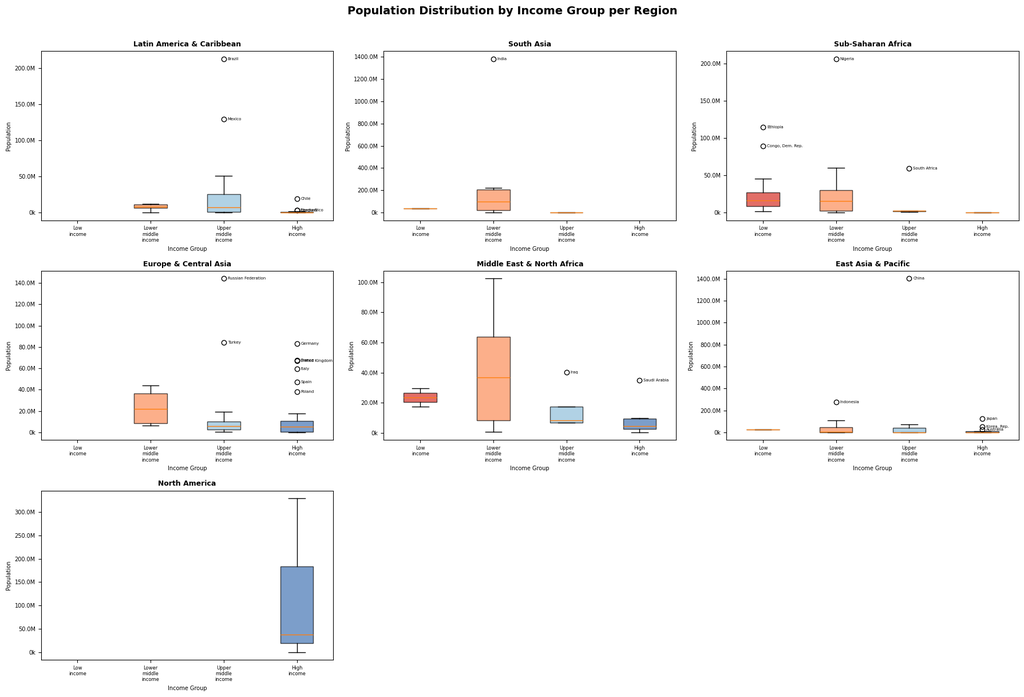

```python
import matplotlib.pyplot as plt
# Keep world_pop unchanged; use a filtered copy for this chart only
world_pop_plot = world_pop.loc[
    world_pop["Year"].eq(latest_year) & world_pop["Region"].notna()
].copy()
# Facet-wrapped boxplot: Population distribution by IncomeGroup, one facet per Region
regions_list = world_pop_plot["Region"].unique()
n_cols = 3
n_rows = -(-len(regions_list) // n_cols)  # ceiling division

fig, axes = plt.subplots(n_rows, n_cols, figsize=(18, 12), sharey=False)
axes = axes.flatten()

for i, region in enumerate(regions_list):
    ax = axes[i]
    region_data = world_pop_plot[world_pop_plot["Region"] == region]

    # Group populations by income group
    groups = [
        region_data[region_data["IncomeGroup"] == ig]["Population"].dropna().values
        for ig in income_order
    ]

    bp = ax.boxplot(groups, labels=[ig.replace(" ", "\n") for ig in income_order], patch_artist=True)

    colors = ["#d73027", "#fc8d59", "#91bfdb", "#4575b4"]
    for patch, color in zip(bp["boxes"], colors):
        patch.set_facecolor(color)
        patch.set_alpha(0.7)

    ax.set_title(region, fontsize=9, fontweight="bold")
    ax.set_xlabel("Income Group", fontsize=7)
    ax.set_ylabel("Population", fontsize=7)
    ax.yaxis.set_major_formatter(plt.FuncFormatter(lambda x, _: f"{x/1e6:.1f}M" if x >= 1e6 else f"{x/1e3:.0f}k"))
    ax.tick_params(axis='x', labelsize=6)
    ax.tick_params(axis='y', labelsize=7)
    # Annotate outliers with country names
    for ig_idx, ig in enumerate(income_order):
        ig_data = region_data[region_data["IncomeGroup"] == ig]["Population"].dropna()
        if ig_data.empty:
            continue
        q1, q3 = ig_data.quantile(0.25), ig_data.quantile(0.75)
        iqr = q3 - q1
        outlier_mask = (ig_data < q1 - 1.5 * iqr) | (ig_data > q3 + 1.5 * iqr)
        outlier_pops = ig_data[outlier_mask]
        for pop_val in outlier_pops:
            country_name = world_pop_plot[
                (world_pop_plot["Region"] == region) &
                (world_pop_plot["IncomeGroup"] == ig) &
                (world_pop_plot["Population"] == pop_val)
            ]["Country Name"].values
            if len(country_name) > 0:
                ax.annotate(
                    country_name[0],
                    xy=(ig_idx + 1, pop_val),
                    xytext=(5, 0),
                    textcoords="offset points",
                    fontsize=5,
                    va="center"
                )
# Hide unused subplots
for j in range(i + 1, len(axes)):
    axes[j].set_visible(False)

plt.suptitle("Population Distribution by Income Group per Region", fontsize=14, fontweight="bold", y=1.01)
plt.tight_layout()
plt.show()
```

## Understand correlations and fit model

We will analyze the correlation of region and income group on population growth/decline through the years.

```
Mean annual population growth rate (%) by Region x IncomeGroup:
IncomeGroup                 Low income  Lower middle income  \
Region
East Asia & Pacific              1.368                1.984
Europe & Central Asia              NaN                1.711
Latin America & Caribbean          NaN                2.095
Middle East & North Africa       2.603                2.493
North America                      NaN                  NaN
South Asia                       2.499                1.978
Sub-Saharan Africa               2.633                2.623

IncomeGroup                 Upper middle income  High income
Region
East Asia & Pacific                       1.608        1.765
Europe & Central Asia                     0.682        0.645
Latin America & Caribbean                 1.500        1.770
Middle East & North Africa                2.966        4.450
North America                               NaN        0.961
South Asia                                3.038          NaN
Sub-Saharan Africa                        2.263        1.448

Share of country-years with population decline (%) by Region x IncomeGroup:
IncomeGroup                 Low income  Lower middle income  \
Region
East Asia & Pacific               0.00                 2.98
Europe & Central Asia              NaN                11.67
Latin America & Caribbean          NaN                 0.00
Middle East & North Africa        6.67                 0.00
North America                      NaN                  NaN
South Asia                       13.33                 1.67
Sub-Saharan Africa                2.19                 1.11

IncomeGroup                 Upper middle income  High income
Region
East Asia & Pacific                        4.38         7.02
Europe & Central Asia                     29.22        15.05
Latin America & Caribbean                  6.32        13.23
Middle East & North Africa                 2.50         2.94
North America                               NaN         7.22
South Asia                                 0.00          NaN
Sub-Saharan Africa                         2.50         6.67

Strongest category correlations with annual growth rate:
Region_Europe & Central Asia        -0.374
Region_Middle East & North Africa    0.286
Region_Sub-Saharan Africa            0.228
IncomeGroup_Low income               0.166
IncomeGroup_Lower middle income      0.145
IncomeGroup_High income             -0.145
IncomeGroup_Upper middle income     -0.110
Region_North America                -0.058
Region_South Asia                    0.041
Region_Latin America & Caribbean    -0.033
dtype: float64
```

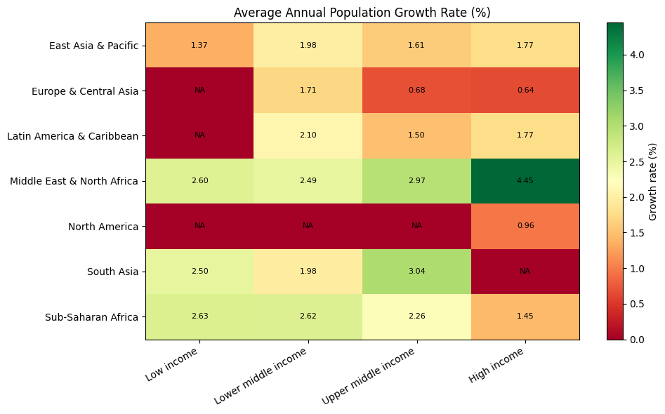

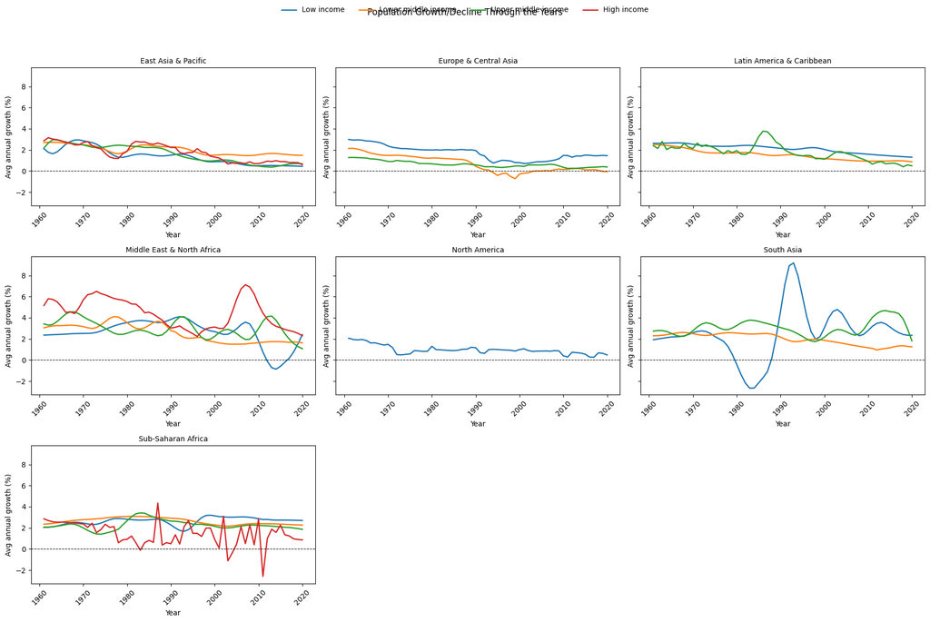

```python
# Compute year-over-year population growth rate for each country
growth_data = world_pop.sort_values(["Country Code", "Year"]).copy()
growth_data["GrowthRatePct"] = growth_data.groupby("Country Code")["Population"].pct_change() * 100
growth_data = growth_data.dropna(subset=["GrowthRatePct"])

# Summary tables
avg_growth_table = (
    growth_data.groupby(["Region", "IncomeGroup"])["GrowthRatePct"]
    .mean()
    .unstack()
    .reindex(index=regions, columns=income_order)
)

decline_share_table = (
    growth_data.assign(Decline=growth_data["GrowthRatePct"] < 0)
    .groupby(["Region", "IncomeGroup"])["Decline"]
    .mean()
    .unstack()
    .reindex(index=regions, columns=income_order) * 100
)

# Correlation of category membership with annual population growth
corr_features = pd.get_dummies(growth_data[["Region", "IncomeGroup"]], dtype=int)
corr_series = corr_features.corrwith(growth_data["GrowthRatePct"]).sort_values(
    key=lambda s: s.abs(), ascending=False
)

print("Mean annual population growth rate (%) by Region x IncomeGroup:")
print(avg_growth_table.round(3))

print("\nShare of country-years with population decline (%) by Region x IncomeGroup:")
print(decline_share_table.round(2))

print("\nStrongest category correlations with annual growth rate:")
print(corr_series.head(10).round(3))

# Heatmap of average growth
heatmap_fig, heatmap_ax = plt.subplots(figsize=(10, 6))
heatmap_values = avg_growth_table.fillna(0)

heatmap_im = heatmap_ax.imshow(heatmap_values, cmap="RdYlGn", aspect="auto")
heatmap_ax.set_xticks(range(len(income_order)))
heatmap_ax.set_xticklabels(income_order, rotation=30, ha="right")
heatmap_ax.set_yticks(range(len(regions)))
heatmap_ax.set_yticklabels(regions)
heatmap_ax.set_title("Average Annual Population Growth Rate (%)")
heatmap_fig.colorbar(heatmap_im, ax=heatmap_ax, label="Growth rate (%)")

for row_idx in range(avg_growth_table.shape[0]):
    for col_idx in range(avg_growth_table.shape[1]):
        original_value = avg_growth_table.iloc[row_idx, col_idx]
        text = "NA" if pd.isna(original_value) else f"{original_value:.2f}"
        heatmap_ax.text(col_idx, row_idx, text, ha="center", va="center", fontsize=8)

plt.tight_layout()
plt.show()

# Growth trend through time by region and income group
growth_by_year = (
    growth_data.groupby(["Year", "Region", "IncomeGroup"], as_index=False)["GrowthRatePct"]
    .mean()
)

trend_fig, trend_axes = plt.subplots(n_rows, n_cols, figsize=(18, 12), sharey=True)
trend_axes = trend_axes.flatten()

for idx, region_name in enumerate(regions):
    trend_ax = trend_axes[idx]
    region_year = growth_by_year[growth_by_year["Region"] == region_name]

    for income_group in income_order:
        income_year = region_year[region_year["IncomeGroup"] == income_group]
        if not income_year.empty:
            trend_ax.plot(
                income_year["Year"],
                income_year["GrowthRatePct"],
                linewidth=1.8,
                label=income_group
            )

    trend_ax.axhline(0, color="black", linestyle="--", linewidth=0.8)
    trend_ax.set_title(region_name, fontsize=10)
    trend_ax.set_xlabel("Year")
    trend_ax.set_ylabel("Avg annual growth (%)")
    trend_ax.tick_params(axis="x", rotation=45)

for idx in range(len(regions), len(trend_axes)):
    trend_axes[idx].set_visible(False)

handles, labels = trend_axes[0].get_legend_handles_labels()
trend_fig.legend(handles, labels, loc="upper center", ncol=4, frameon=False)
trend_fig.suptitle("Population Growth/Decline Through the Years", y=0.99)
trend_fig.tight_layout(rect=[0, 0, 1, 0.95])
plt.show()
```

```python
# Use absolute correlation with GrowthRatePct as a proxy for feature significance
abs_corr = corr_series.abs().sort_values(ascending=False)

top_feature = abs_corr.index[0]
top_strength = abs_corr.iloc[0]
top_family = "Region" if top_feature.startswith("Region_") else "IncomeGroup"

region_corr = abs_corr[abs_corr.index.str.startswith("Region_")]
income_corr = abs_corr[abs_corr.index.str.startswith("IncomeGroup_")]

summary = pd.DataFrame({
    "FeatureFamily": ["Region", "IncomeGroup"],
    "MaxAbsCorr": [region_corr.max(), income_corr.max()],
    "MeanAbsCorr": [region_corr.mean(), income_corr.mean()]
}).sort_values("MaxAbsCorr", ascending=False)

print("Most significant single feature (by absolute correlation):")
print(f"{top_feature} -> |corr| = {top_strength:.3f} ({top_family})\n")

print("Region vs IncomeGroup overall strength:")
print(summary.to_string(index=False))
```

```
Most significant single feature (by absolute correlation):
Region_Europe & Central Asia -> |corr| = 0.374 (Region)

Region vs IncomeGroup overall strength:
FeatureFamily  MaxAbsCorr  MeanAbsCorr
       Region    0.374398     0.145858
  IncomeGroup    0.165529     0.141414
```

They show weak correlation. Let's try combining income group and region.

```
Top combined (Region + IncomeGroup) correlations with GrowthRatePct:
RI_Europe & Central Asia | High income                -0.303
RI_Middle East & North Africa | High income            0.295
RI_Europe & Central Asia | Upper middle income        -0.188
RI_Sub-Saharan Africa | Low income                     0.162
RI_Sub-Saharan Africa | Lower middle income            0.140
RI_Middle East & North Africa | Upper middle income    0.091
RI_Middle East & North Africa | Lower middle income    0.069
RI_North America | High income                        -0.058
RI_Latin America & Caribbean | Upper middle income    -0.055
RI_South Asia | Upper middle income                    0.048
dtype: float64

Strength comparison:
Best single-feature |corr|:   0.374
Best combined-feature |corr|: 0.303

Top combined groups by mean growth rate:
                                                   mean    std  count
RegionIncome
Middle East & North Africa | High income          4.450  3.643    476
South Asia | Upper middle income                  3.038  0.739     60
Middle East & North Africa | Upper middle income  2.966  1.589    240
Sub-Saharan Africa | Low income                   2.633  1.179   1371
Sub-Saharan Africa | Lower middle income          2.623  0.833   1080
Middle East & North Africa | Low income           2.603  1.719    120
South Asia | Low income                           2.499  2.415     60
Middle East & North Africa | Lower middle income  2.493  1.559    390
Sub-Saharan Africa | Upper middle income          2.263  1.405    360
Latin America & Caribbean | Lower middle income   2.095  0.720    360
```

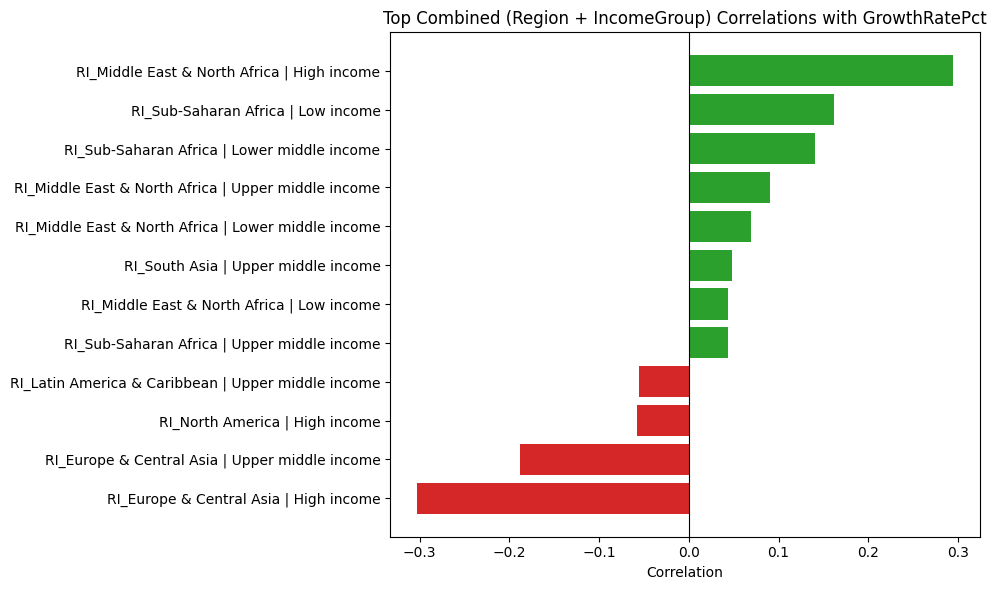

```python
# Combine Region + IncomeGroup into one interaction feature
growth_data["RegionIncome"] = growth_data["Region"] + " | " + growth_data["IncomeGroup"]

# Correlation of interaction categories with annual growth
combo_dummies = pd.get_dummies(growth_data["RegionIncome"], prefix="RI", dtype=int)
combo_corr = combo_dummies.corrwith(growth_data["GrowthRatePct"]).sort_values(
    key=lambda s: s.abs(), ascending=False
)
combo_abs_corr = combo_corr.abs()

print("Top combined (Region + IncomeGroup) correlations with GrowthRatePct:")
print(combo_corr.head(10).round(3))

print("\nStrength comparison:")
print(f"Best single-feature |corr|:   {abs_corr.max():.3f}")
print(f"Best combined-feature |corr|: {combo_abs_corr.iloc[0]:.3f}")

# Optional: inspect average growth by the combined group
combo_growth_table = (
    growth_data.groupby("RegionIncome")["GrowthRatePct"]
    .agg(["mean", "std", "count"])
    .sort_values("mean", ascending=False)
)
print("\nTop combined groups by mean growth rate:")
print(combo_growth_table.head(10).round(3))

# Visualize top combined correlations
top_n = 12
top_combo = combo_corr.head(top_n).sort_values()

plt.figure(figsize=(10, 6))
colors = ["#2ca02c" if v > 0 else "#d62728" for v in top_combo.values]
plt.barh(top_combo.index, top_combo.values, color=colors)
plt.axvline(0, color="black", linewidth=0.8)
plt.title("Top Combined (Region + IncomeGroup) Correlations with GrowthRatePct")
plt.xlabel("Correlation")
plt.tight_layout()
plt.show()
```

Correlation is still shown low. The reason may be because the region and income group have non-linear relation with the population growth. Let's use violin chart to visualize it better.

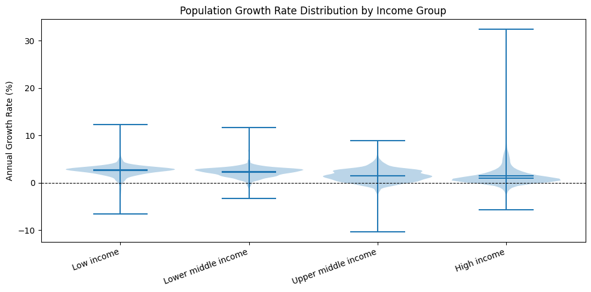

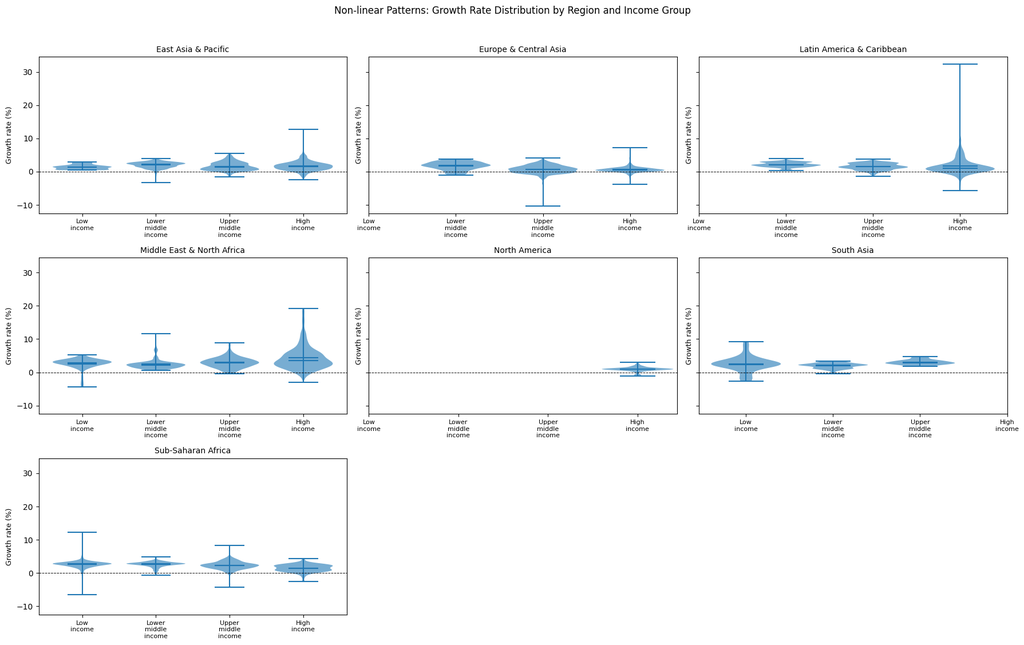

```python
# Violin charts to inspect non-linear distribution patterns in growth rates
plot_data = growth_data.dropna(subset=["GrowthRatePct", "Region", "IncomeGroup"]).copy()

# 1) Overall distribution by income group
overall_groups = [
    plot_data.loc[plot_data["IncomeGroup"] == ig, "GrowthRatePct"].values
    for ig in income_order
]

plt.figure(figsize=(10, 5))
v1 = plt.violinplot(overall_groups, showmeans=True, showmedians=True, widths=0.85)
plt.xticks(range(1, len(income_order) + 1), income_order, rotation=20, ha="right")
plt.axhline(0, color="black", linestyle="--", linewidth=0.8)
plt.ylabel("Annual Growth Rate (%)")
plt.title("Population Growth Rate Distribution by Income Group")
plt.tight_layout()
plt.show()

# 2) Faceted by region (income groups on x-axis)
n_cols = 3
n_rows = -(-len(regions) // n_cols)  # ceiling division
fig, axes = plt.subplots(n_rows, n_cols, figsize=(18, 11), sharey=True)
axes = axes.flatten()

for i, region_name in enumerate(regions):
    ax = axes[i]
    region_df = plot_data[plot_data["Region"] == region_name]

    series_list, positions = [], []
    for pos, ig in enumerate(income_order, start=1):
        vals = region_df.loc[region_df["IncomeGroup"] == ig, "GrowthRatePct"].dropna().values
        if len(vals) > 0:
            series_list.append(vals)
            positions.append(pos)

    if series_list:
        vp = ax.violinplot(series_list, positions=positions, showmeans=True, showmedians=True, widths=0.8)
        for body in vp["bodies"]:
            body.set_alpha(0.6)

    ax.set_xticks(range(1, len(income_order) + 1))
    ax.set_xticklabels([ig.replace(" ", "\n") for ig in income_order], fontsize=8)
    ax.axhline(0, color="black", linestyle="--", linewidth=0.7)
    ax.set_title(region_name, fontsize=10)
    ax.set_ylabel("Growth rate (%)", fontsize=9)

for j in range(i + 1, len(axes)):
    axes[j].set_visible(False)

plt.suptitle("Non-linear Patterns: Growth Rate Distribution by Region and Income Group", y=1.02)
plt.tight_layout()
plt.show()
```

Growth distributions overlap substantially across groups, but there are still systematic differences in central tendency and extremes.

Let's also check if the top combined feature (Region + IncomeGroup) has a non-linear relationship with growth rate by plotting growth rates for the top combined category against the rest.

```
                                          count   mean  median    std
Group
All other groups                          10697  2.052   2.047  1.789
Top: Europe & Central Asia | High income   2220  0.645   0.547  0.905
```

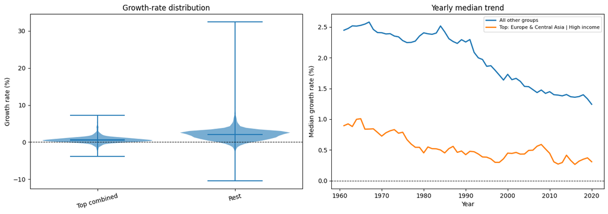

```python
# Compare growth-rate distribution: top combined category vs all other categories
top_combo_feature = combo_abs_corr.index[0].replace("RI_", "")
compare_df = growth_data[["Year", "GrowthRatePct", "RegionIncome"]].copy()
compare_df["Group"] = compare_df["RegionIncome"].eq(top_combo_feature).map({
    True: f"Top: {top_combo_feature}",
    False: "All other groups"
})

# Quick summary
summary_compare = compare_df.groupby("Group")["GrowthRatePct"].agg(["count", "mean", "median", "std"])
print(summary_compare.round(3))

# Plot distributions + yearly trend (median) to inspect potential non-linearity
fig, axes = plt.subplots(1, 2, figsize=(14, 5))

# 1) Distribution comparison
top_vals = compare_df.loc[compare_df["Group"].str.startswith("Top:"), "GrowthRatePct"].values
rest_vals = compare_df.loc[compare_df["Group"] == "All other groups", "GrowthRatePct"].values

v = axes[0].violinplot([top_vals, rest_vals], showmeans=True, showmedians=True, widths=0.8)
for body in v["bodies"]:
    body.set_alpha(0.6)

axes[0].set_xticks([1, 2])
axes[0].set_xticklabels(["Top combined", "Rest"], rotation=15)
axes[0].axhline(0, color="black", linestyle="--", linewidth=0.8)
axes[0].set_ylabel("Growth rate (%)")
axes[0].set_title("Growth-rate distribution")

# 2) Yearly median trend comparison
yearly_median = (
    compare_df.groupby(["Year", "Group"], as_index=False)["GrowthRatePct"]
    .median()
)

for group_name, g in yearly_median.groupby("Group"):
    axes[1].plot(g["Year"], g["GrowthRatePct"], linewidth=2, label=group_name)

axes[1].axhline(0, color="black", linestyle="--", linewidth=0.8)
axes[1].set_xlabel("Year")
axes[1].set_ylabel("Median growth rate (%)")
axes[1].set_title("Yearly median trend")
axes[1].legend(fontsize=8)

plt.tight_layout()
plt.show()
```

Let's use ANOVA test.

```python
from scipy.stats import f_oneway

# ANOVA tests on annual population growth rate
import statsmodels.api as sm
import statsmodels.formula.api as smf

anova_df = growth_data.dropna(subset=["GrowthRatePct", "Region", "IncomeGroup"]).copy()

# 1) One-way ANOVA: IncomeGroup effect
income_samples = [
    anova_df.loc[anova_df["IncomeGroup"] == g, "GrowthRatePct"].values
    for g in income_order
    if (anova_df["IncomeGroup"] == g).any()
]
f_income, p_income = f_oneway(*income_samples)
print(f"One-way ANOVA (IncomeGroup): F={f_income:.4f}, p={p_income:.4e}")

# 2) One-way ANOVA: Region effect
region_samples = [
    anova_df.loc[anova_df["Region"] == r, "GrowthRatePct"].values
    for r in regions
    if (anova_df["Region"] == r).any()
]
f_region, p_region = f_oneway(*region_samples)
print(f"One-way ANOVA (Region):      F={f_region:.4f}, p={p_region:.4e}")

# 3) Two-way ANOVA with interaction: Region + IncomeGroup + Region*IncomeGroup
model = smf.ols("GrowthRatePct ~ C(Region) * C(IncomeGroup)", data=anova_df).fit()
anova_table = sm.stats.anova_lm(model, typ=2)

print("\nTwo-way ANOVA (Type II):")
print(anova_table.round(6))
```

```
One-way ANOVA (IncomeGroup): F=284.6961, p=5.8498e-179
One-way ANOVA (Region):      F=615.6213, p=0.0000e+00

Two-way ANOVA (Type II):
                                sum_sq       df           F   PR(>F)
C(Region)                  3257.850537      6.0  238.898963  0.00000
C(IncomeGroup)              225.537995      3.0   33.077511  0.00000
C(Region):C(IncomeGroup)      0.672020     18.0    0.016426  0.89802
Residual                  29308.054281  12895.0         NaN      NaN
```

Population growth rates differ significantly across both regions and income groups, with region being the dominant factor. The effects of region and income are additive and independent, as no significant interaction is observed between them.

Let's check the effect size.

```python
eta2_region = 3257.85 / (3257.85 + 29308.05)
eta2_income = 225.54 / (225.54 + 29308.05)

print(f"\nEffect size (eta-squared):")
print(f"Region: {eta2_region:.3f}")
print(f"IncomeGroup: {eta2_income:.3f}")
```

```
Effect size (eta-squared):
Region: 0.100
IncomeGroup: 0.008
```

Population growth varies significantly across regions, with region explaining a moderate portion of the variance (~10%). Income group differences are statistically significant but have a negligible practical effect (~0.8%). Overall, most variation in population growth is driven by factors beyond region and income classification.

TODO: Because 10% is a low impact. We will find more categorical data.

I am assuming fertility, median age, migration?, and urbanization will be meaningful addition.